# Homework 2 Report

## Name

Maya Glenn

### Setup

Read in the data with `read_csv()` and store the data as an R object named `dataset`. Check the data to make sure all of the expected observations and variables are there.

```r
## Load the data and any necessary packages here.
library(tidyverse)
library(dplyr)
dataset <- read.csv("/Users/mayaglenn/SDS375/homework2/MAACS/docs/maacs.csv.gz")

# Check the data
dim(dataset)
```

```
## [1] 150  10
```

```r
head(dataset)
```

```
##         id   age gender fev1 eNO cough_days   pm25    no2 mouse mouse_allergic
## 1 fd171e2d 14.72   male 1.78 141          2 15.560     NA  2423            yes
## 2 a66fc33a 13.56 female 2.12  68          8 18.890 12.827   939            yes
## 3 fc038e68 14.50   male 2.73 210          2 17.808     NA   200             no
## 4 8e28b8c2 13.96 female 2.36  23          0 13.956     NA    NA             no
## 5 b2699b54 16.63 female 3.13  18         14 17.864 30.976 10371             no
## 6 7d4f3508 16.56 female 2.59 128          0 43.784 10.590  4789            yes
```

## Part 1

We will first consider the relationship between FEV1 and age. In general, it is expected that as children get older (and hence, larger in size), their FEV1 values should get higher.

Consider the statement “FEV1 values in children are higher in older children relative to younger children”.

Write a function in R that takes the `dataset` object as an argument and returns `TRUE` if the statement above is true for the dataset and `FALSE` otherwise.

NOTE: In order to write this function, you will need to translate the statement above into something that can be checked with the data. There are many ways in which you can do that translation correctly and you only need to pick one way here.

NOTE: For this part, do not use any plots.

```r
## Write your function here

fev1_func <- function(dataset) {
  # Find the median age
  median_age <- median(dataset$age, na.rm = TRUE)

  # Split into younger and older groups
  younger <- dataset$fev1[dataset$age <= median_age]
  older <- dataset$fev1[dataset$age > median_age]

  # Compare mean FEV1 values
  return(mean(older, na.rm = TRUE) > mean(younger, na.rm = TRUE))
}
```

## Part 2

Fit a linear regression model with FEV1 as the outcome and age as a predictor.

How much does FEV1 change for a 1-year increase in the child’s age?

```r
## Add your code here

model <- lm(fev1 ~ age, data = dataset)
slope <- coef(model)["age"]
```

Write your data analysis statement interpreting the regression model here:

On average, for a 1-year increase in the child’s age, FEV1 increases by 0.1711623 liters.

## Part 3

Develop **three** supporting premises derived from the data that support the statement you wrote in Part 2. These can be plots, other summary statistics, or model results.

NOTE: At least one supporting premise should use a plot.

```r
## Add your code here

#premise one: significant p-value
unname(summary(model)$coefficients["age", "Pr(>|t|)"])
```

```
## [1] 1.271776e-31
```

```r
#premise two: correlation
cor(dataset$age, dataset$fev1, use = "complete.obs")
```

```
## [1] 0.8059696
```

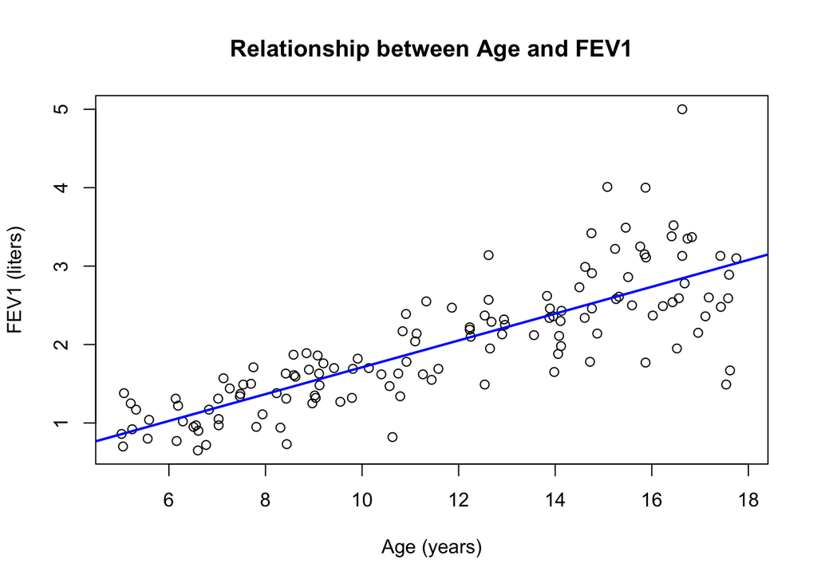

```r
#premise three: plot
plot(dataset$age, dataset$fev1,
     xlab = "Age (years)", ylab = "FEV1 (liters)",
     main = "Relationship between Age and FEV1")
abline(model, col = "blue", lwd = 2)
```

Write the three supporting premise statements here:

1. The p value is less than 2e-16, which is also less than an Alpha of 0.01 or 0.05. This indicates that the positive relationship between age and FEV1 is statistically significant.
2. The correlation between age and FEV1 is strong and positive, indicating that there is a direct positive association between age and FEV1.
3. The plot illustrates a positive trend among the data points, where as age increases, so do the FEV1 levels.

## Part 4

For each of the supporting premises above, write a function that takes the `dataset` object as an argument and returns `TRUE` if the supporting premise statement above is true for the dataset and `FALSE` otherwise.

For statements involving plots, instead of returning `TRUE` or `FALSE`, you function should do two things:

1. Produce the plot that is used in the statement
2. Produce a hypothetical version of the plot in the event that the statement is true. This can be done using simulated data or by simply hand drawing a plot.

```r
## Function for supporting premise statement 1

summary_func <- function(dataset) {
  model <- lm(fev1 ~ age, data = dataset)
  slope <- unname(coef(model)["age"])
  p <- unname(summary(model)$coefficients["age", "Pr(>|t|)"])
  return(slope > 0 & p < 0.01)
}
```

```r
## Function for supporting premise statement 2

correlation_func <- function(dataset) {
  correlation <- cor(dataset$age, dataset$fev1, use = "complete.obs")
  return(correlation>0)
}
```

```r
## Function for supporting premise statement 3

plot_func <- function(dataset) {
  #actual plot
  plot(dataset$age, dataset$fev1,
       xlab = "Age (years)", ylab = "FEV1 (liters)",
       main = "Relationship between Age and FEV1")
  abline(lm(fev1 ~ age, data = dataset), col = "blue", lwd = 2)

  # Hypothetical plot that simulates what "true" would look like
  age_sim <- seq(min(dataset$age), max(dataset$age), length.out = 50)
  fev1_sim <- 0.5 * age_sim + rnorm(50, mean = 0, sd = 0.5)
  plot(age_sim, fev1_sim,
       xlab = "Age (years)", ylab = "FEV1 (liters)",
       main = "Hypothetical Relationship if Statement is True")
  abline(lm(fev1_sim ~ age_sim), col = "red", lwd = 2)
}
```

Execute each of your function and show that the produce the expected output.

```r
summary_func(dataset)
```

```
## [1] TRUE
```

```r
correlation_func(dataset)
```

```
## [1] TRUE
```

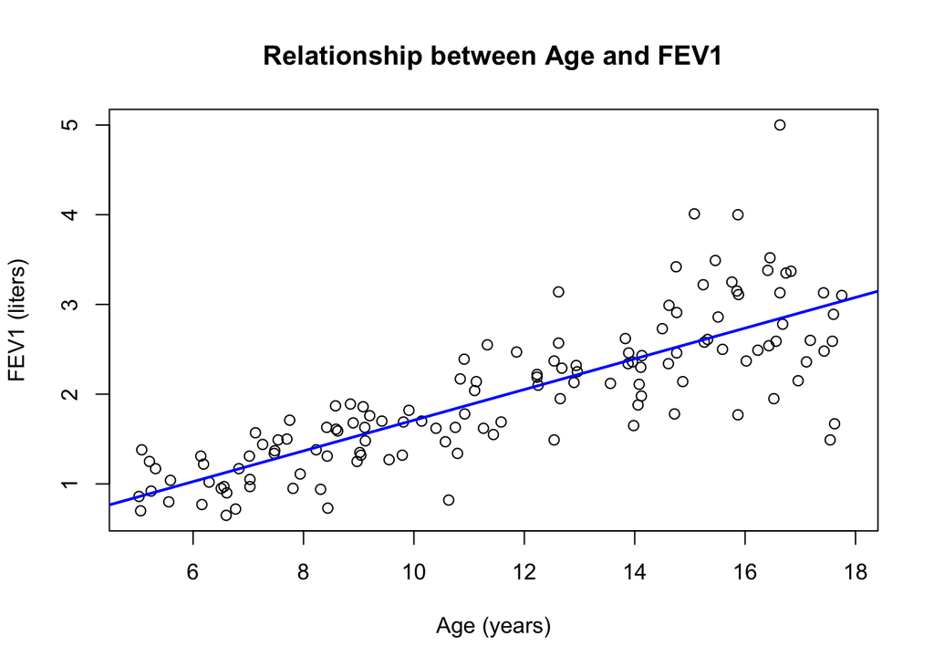

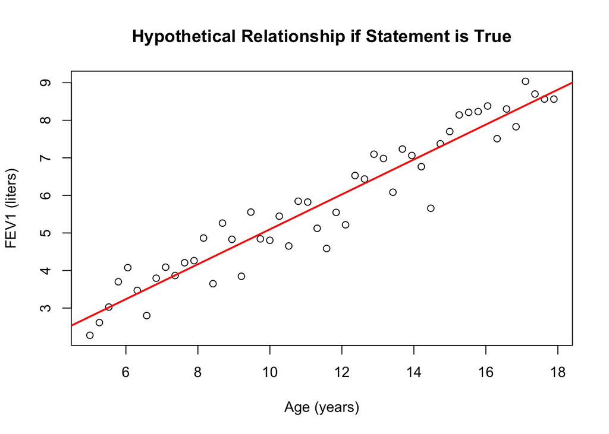

```r
plot_func(dataset)
```

All functions produce the expected output.

Function 1 checks to make sure that the p-value is less than 0.01 (and that the slope is positive), which confirms that premise one is TRUE.

Function 2 checks to make sure the correlation is positive, confirming that premise two is TRUE.

Function 3 plots the relationship between age and fev1, and shows the regression line in blue, confirming that the relationship is positive. It also simulates a plot with a positive relationship between the two variables, in the case that the premise is true.

## Part 5

Describe one alternative to the primary statement “FEV1 values in children are higher in older children relative to younger children”.

Create a fault tree for the alternative outcome describing how the alternative outcome could be realized in the data even if the primary statement were true.

Your fault tree should be created as a separate image and does not need to be created in R. Upload the image of the fault tree to Canvas.